# Predicting exercise performance using machine learning algorithms

André Amorim

Using devices such as Jawbone Up, Nike FuelBand, and Fitbit it is now possible to collect a large amount of data about personal activity relatively inexpensively. These type of devices are part of the quantified self movement - a group of enthusiasts who take measurements about themselves regularly to improve their health, to find patterns in their behavior, or because they are tech geeks. One thing that people regularly do is quantify how much of a particular activity they do, but they rarely quantify how well they do it. In this project, your goal will be to use data from accelerometers on the belt, forearm, arm, and dumbell of 6 participants. They were asked to perform barbell lifts correctly and incorrectly in 5 different ways. More information is available from the website here: http://groupware.les.inf.puc-rio.br/har (see the section on the Weight Lifting Exercise Dataset). The goal of your project is to predict the manner in which they did the exercise. This is the “classe” variable in the training set. Tree predicting models were tested and the one with the best results was used to predict 20 test cases. The used modesl were a classification tree, a random forest and a boosting model. As expected, the random tree and boosting models yielded the best results, being the random tree slightly more accurate. However, in the end all the testing cases were correclty predicted either usingthe boosting model or the random tree.

### Experimental setup

Six young health participants were asked to perform one set of 10 repetitions of the Unilateral Dumbbell Biceps Curl in five different fashions: exactly according to the specification (Class A), throwing the elbows to the front (Class B), lifting the dumbbell only halfway (Class C), lowering the dumbbell only halfway (Class D) and throwing the hips to the front (Class E). Class A corresponds to the specified execution of the exercise, while the other 4 classes correspond to common mistakes. Participants were supervised by an experienced weight lifter to make sure the execution complied to the manner they were supposed to simulate. The exercises were performed by six male participants aged between 20-28 years, with little weight lifting experience. We made sure that all participants could easily simulate the mistakes in a safe and controlled manner by using a relatively light dumbbell (1.25kg).

Read more: http://groupware.les.inf.puc-rio.br/har#ixzz3vZ4yWERt

### Getting the data

The data was obtained from the “Weight Lifting Exercises dataset, available at the webpage of the”Human Activity Recognition" project (http://groupware.les.inf.puc-rio.br/har).

```r
# Load necessary packages
require(caret)
require(rpart)
require(rattle)
```

```r
require(ggplot2)
# Load the data
training_url = "https://d396qusza40orc.cloudfront.net/predmachlearn/pml-training.csv"
testing_url = "https://d396qusza40orc.cloudfront.net/predmachlearn/pml-testing.csv"
#training_file = url(training_url)
#testing_file = url(testing_url)
training_file = "D:/Downloads/pml-training.csv"
testing_file = "D:/Downloads/pml-testing.csv"
trainingSet = read.csv(training_file, na.strings=c("NA",""), header=TRUE)
testingSet = read.csv(testing_file, na.strings=c("NA",""), header=TRUE)
```

### Exploration of the outcome variable

A brief exploration of the dataset was performed to have an idea about the behaviour of the outcome variable, “classe”. We can see that it is a factor variable with 5 levels. All of them have a similar number of observations, with the category “A” with some more observations. Remind that this category corresponds to the right performance of the exercise.

```r
# Initial exploration of the dataset
names(trainingSet)
```

[output not shown]

```r
# Start by exploring the outcome. It is a categoric variable with 5 categories: A,B,C,D,E.
head(trainingSet$classe)
```

```
## [1] A A A A A A
## Levels: A B C D E
```

```r
summary(trainingSet$classe)
```

```
##    A    B    C    D    E
## 5580 3797 3422 3216 3607
```

### Cleaning the data

A lot of variables exist in the dataset. Some of them are related with the author’s data processing procedures and are useless for us. The time window, the kurtosis, skewness, maximum and minimuns of variables are examples of this variables. These variables are computed from multiple observations and thus have a smaller length compared to the length of the obervations. The missing values are defined as “NA”. Other variables not important for our analysis are the ones related with the data acquisiton, such as the name of the subject, the index variable or time stamps. Variables related with the author’s data processing procedures can be removed by looking for missing values. Since they have a smaller length compared with the lenght of the observations, they have a lot of missing values. A small exploration of the dataset shows that they have high proportion of missing values. All other variables are complete and have no missing values. We can therefore define a threshold of proportion of missing values in order to remove them. A threshold of 70% is enough. Data acquisition variables correspond to just the first 7 columns of the dataset and are easily removed. Both the provided training and testing sets were cleaned the same way.

```r
# Cleaning the data
# Remove empty variables or variables with more than 70% of missing values
threshold = 0.70
NA_counts = colSums(is.na(trainingSet))
NA_counts_fraction = NA_counts/dim(trainingSet)[1]
columns_keep = NA_counts_fraction<threshold
trainingSet_clean1 <- trainingSet[,columns_keep]
testingSet_clean1 = testingSet[,columns_keep]
# Remove the first 7 variables. They are related with the author's data analysis and are here unecessary
trainingSet_clean2 <- trainingSet_clean1[,-7:-1]
testingSet_clean2 = testingSet_clean1[,-7:-1]
names(trainingSet_clean2)
```

[output not shown]

### Exploratory analysis

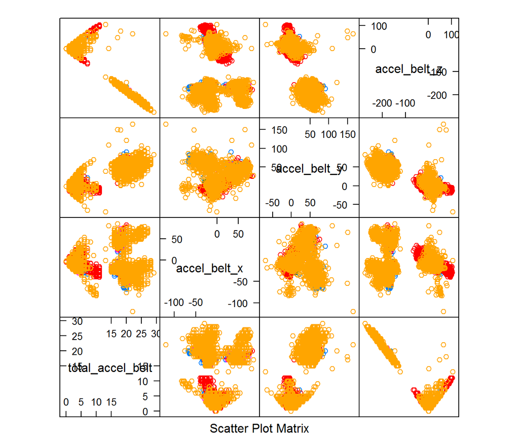

```r
# Exploratory analysis
accel_belt_components = c("total_accel_belt", "accel_belt_x", "accel_belt_y", "accel_belt_z")
accel_arm_components = c("total_accel_arm", "accel_arm_x", "accel_arm_y", "accel_arm_z")
accel_dumbbell_components = c("total_accel_dumbbell", "accel_dumbbell_x", "accel_dumbbell_y", "accel_dumbbell_z")
accel_forearm_components = c("total_accel_forearm", "accel_forearm_x", "accel_forearm_y", "accel_forearm_z")
# Evaluating if the total component of movement depends on the x,y,z components
featurePlot(x=trainingSet_clean2[,accel_belt_components],y = trainingSet_clean2$classe,plot="pairs")
```

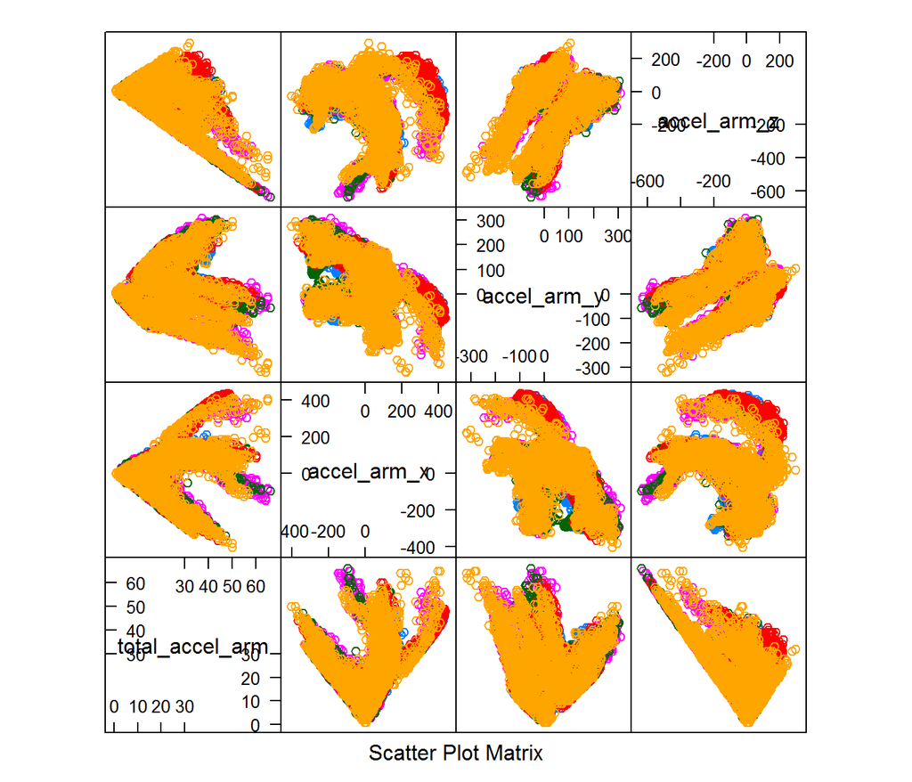

```r
featurePlot(x=trainingSet_clean2[,accel_arm_components],y = trainingSet_clean2$classe,plot="pairs")
```

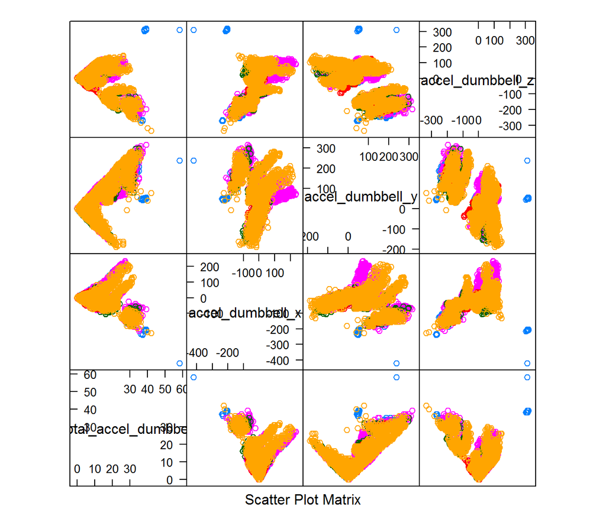

```r
featurePlot(x=trainingSet_clean2[,accel_dumbbell_components],y = trainingSet_clean2$classe,plot="pairs")
```

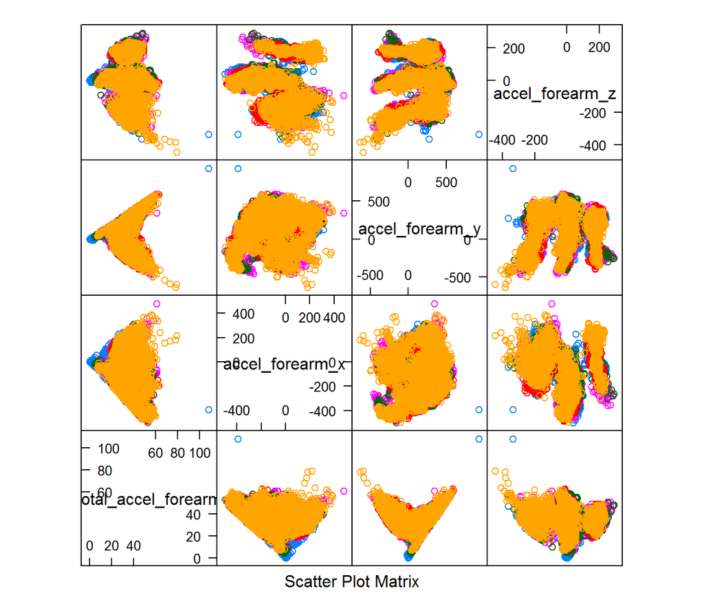

```r
featurePlot(x=trainingSet_clean2[,accel_forearm_components],y = trainingSet_clean2$classe,plot="pairs")
```

```r
# Remove variables with the term "total"
trainingSet_clean3 = trainingSet_clean2[,-grep("total",names(trainingSet_clean2))]
testingSet_clean3 = testingSet_clean2[,-grep("total",names(testingSet_clean2))]
# Check for covariates that have virtually no variablility
nsv <- nearZeroVar(trainingSet_clean3, saveMetrics=TRUE)
```

### Machine learning algoritm

Since we are working with a categoric outcome, a random tree model seems appropriate. A simple tree classifier is going to be tested due to its simple interpretability. Then, a more efficient random forest model will be used as the main model. A boosting model will also be used, to compare with the random forest model. The first step is ti split the data into a training set and a testing set. Only 30% of the provided training set was used, due to computation time reasons. The provided testing set is let untouched for now. It will be only used to predict the 20 testing cases. From the 30% of the training data, we are going to build a predicting model. We splitted it into a training and setting subsets, 60% for training and 40% for testing. They will be called as the training and testing data. Since splitting is random, a seed is set before, for reproducibility. This seed is going to be used for the rest of this study. All variables were coerced to numeric format (except the outcome, which is a factor). This facilitates their manipulation by the prediction models.

```r
# Setting the seed
set.seed(12345)

# Coerce the variables to numeric, except the outcome
for (i in 1:(length(trainingSet_clean3)-1)) {
  trainingSet_clean3[,i] = as.numeric(trainingSet_clean3[,i])
}

# Splitting the data
# The dataset is very big. Lets create a smaller dataset of about 30% of the original
trainingIdx1 = createDataPartition(trainingSet_clean3$classe, p=0.30, list=FALSE)
trainingData2 = trainingSet_clean3[trainingIdx1,]
# Splitting into training and testing dataset
trainingIdx2 = createDataPartition(trainingData2$classe, p=0.60, list=FALSE)
trainingData = trainingData2[trainingIdx2,]
testingData = trainingData2[-trainingIdx2,]
dim(trainingData)
```

```
## [1] 3535   49
```

```r
dim(testingData)
```

```
## [1] 2354   49
```

The training data was then used to train the prediction model. First, the tree model was created, then the random forest and finally the boosting model. A 5 fold cross-validation was used. The remaining training options were let with the default settings of the “caret” package. The tree model was analysed due to its simplicity and interpretability. Looking at he tree, we see it is extremely simple and it doen’t include category “D” of the outcome. This obviously is not a good model, since as it was seen in the exploratory of the outcome, all categories have a similar number of observations. A better model seems to be needed.

```r
# Training
# Train the data with a simple tree classifier. It is easy to interpret
modelFit = train(classe~., data = trainingData, method = "rpart", trControl=trainControl(method="cv",number=5))
print(modelFit)
```

```
## CART
##
## 3535 samples
##   48 predictor
##    5 classes: 'A', 'B', 'C', 'D', 'E'
##
## No pre-processing
## Resampling: Cross-Validated (5 fold)
## Summary of sample sizes: 2828, 2829, 2827, 2828, 2828
## Resampling results across tuning parameters:
##
##   cp          Accuracy   Kappa       Accuracy SD  Kappa SD
##   0.03399209  0.5219364  0.38090298  0.02265393   0.03922590
##   0.06073781  0.4183539  0.21157354  0.06853388   0.11419477
##   0.12015810  0.3168319  0.04972785  0.04461685   0.06820992
##
## Accuracy was used to select the optimal model using  the largest value.
## The final value used for the model was cp = 0.03399209.
```

```r
print(modelFit$finalModel)
```

```
## n= 3535
##
## node), split, n, loss, yval, (yprob)
##       * denotes terminal node
##
##  1) root 3535 2530 A (0.28 0.19 0.17 0.16 0.18)
##    2) roll_belt< 129.5 3211 2216 A (0.31 0.21 0.19 0.18 0.1)
##      4) pitch_forearm< -34 273    0 A (1 0 0 0 0) *
##      5) pitch_forearm>=-34 2938 2216 A (0.25 0.23 0.21 0.2 0.11)
##       10) magnet_dumbbell_y< 423.5 2443 1739 A (0.29 0.18 0.24 0.19 0.099)
##         20) roll_forearm< 123.5 1532  908 A (0.41 0.19 0.18 0.17 0.055) *
##         21) roll_forearm>=123.5 911  594 C (0.088 0.16 0.35 0.23 0.17) *
##       11) magnet_dumbbell_y>=423.5 495  253 B (0.036 0.49 0.046 0.24 0.19) *
##    3) roll_belt>=129.5 324   10 E (0.031 0 0 0 0.97) *
```

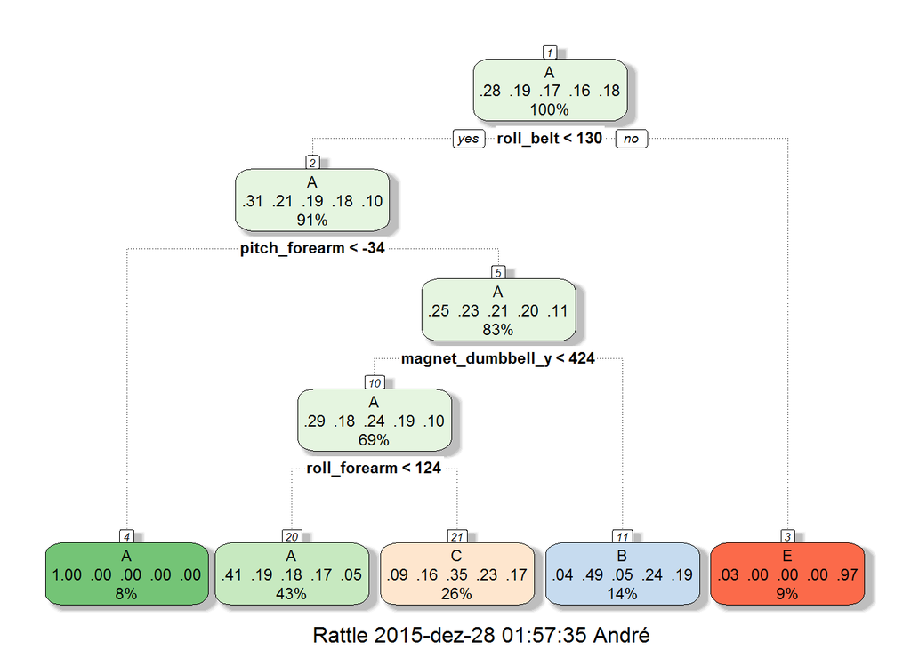

```r
fancyRpartPlot(modelFit$finalModel)
```

```r
# Train the data with a random forest classifier.
modelFit2 = train(classe~., data = trainingData, method = "rf", trControl=trainControl(method="cv",number=5), prox=TRUE)
# Train the data with a boosting classifier.
modelFit3 = train(classe~., data = trainingData, method = "gbm", trControl=trainControl(method="cv",number=5), verbose=FALSE)
```

```r
# Testing the models
# Model 1
predictions1 <- predict(modelFit, newdata=testingData)
confusionMatrix(predictions1, testingData$classe)
```

```
## Confusion Matrix and Statistics
##
##           Reference
## Prediction   A   B   C   D   E
##          A 586 174 181 179  68
##          B  21 161  13  73  54
##          C  54 121 216 134  97
##          D   0   0   0   0   0
##          E   8   0   0   0 214
##
## Overall Statistics
##
##                Accuracy : 0.5
##                  95% CI : (0.4796, 0.5204)
##     No Information Rate : 0.2842
##     P-Value [Acc > NIR] : < 2.2e-16
##
##                   Kappa : 0.3479
##  Mcnemar's Test P-Value : NA
##
## Statistics by Class:
##
##                      Class: A Class: B Class: C Class: D Class: E
## Sensitivity            0.8759  0.35307  0.52683    0.000  0.49423
## Specificity            0.6427  0.91517  0.79115    1.000  0.99584
## Pos Pred Value         0.4933  0.50000  0.34727      NaN  0.96396
## Neg Pred Value         0.9288  0.85482  0.88799    0.836  0.89728
## Prevalence             0.2842  0.19371  0.17417    0.164  0.18394
## Detection Rate         0.2489  0.06839  0.09176    0.000  0.09091
## Detection Prevalence   0.5047  0.13679  0.26423    0.000  0.09431
## Balanced Accuracy      0.7593  0.63412  0.65899    0.500  0.74503
```

```r
# Model 2
predictions2 <- predict(modelFit2, newdata=testingData)
confusionMatrix(predictions2, testingData$classe)
```

```
## Confusion Matrix and Statistics
##
##           Reference
## Prediction   A   B   C   D   E
##          A 663  13   0   0   0
##          B   6 428   8   0   0
##          C   0  10 401   9   2
##          D   0   4   1 377   4
##          E   0   1   0   0 427
##
## Overall Statistics
##
##                Accuracy : 0.9754
##                  95% CI : (0.9683, 0.9812)
##     No Information Rate : 0.2842
##     P-Value [Acc > NIR] : < 2.2e-16
##
##                   Kappa : 0.9688
##  Mcnemar's Test P-Value : NA
##
## Statistics by Class:
##
##                      Class: A Class: B Class: C Class: D Class: E
## Sensitivity            0.9910   0.9386   0.9780   0.9767   0.9861
## Specificity            0.9923   0.9926   0.9892   0.9954   0.9995
## Pos Pred Value         0.9808   0.9683   0.9502   0.9767   0.9977
## Neg Pred Value         0.9964   0.9854   0.9953   0.9954   0.9969
## Prevalence             0.2842   0.1937   0.1742   0.1640   0.1839
## Detection Rate         0.2816   0.1818   0.1703   0.1602   0.1814
## Detection Prevalence   0.2872   0.1878   0.1793   0.1640   0.1818
## Balanced Accuracy      0.9917   0.9656   0.9836   0.9861   0.9928
```

```r
# Model 3
predictions3 <- predict(modelFit3, newdata=testingData)
confusionMatrix(predictions3, testingData$classe)
```

```
## Confusion Matrix and Statistics
##
##           Reference
## Prediction   A   B   C   D   E
##          A 650  20   0   0   0
##          B  11 414  11   0   3
##          C   2  17 397  20   8
##          D   5   2   2 363  12
##          E   1   3   0   3 410
##
## Overall Statistics
##
##                Accuracy : 0.949
##                  95% CI : (0.9394, 0.9576)
##     No Information Rate : 0.2842
##     P-Value [Acc > NIR] : < 2.2e-16
##
##                   Kappa : 0.9355
##  Mcnemar's Test P-Value : 7.42e-06
##
## Statistics by Class:
##
##                      Class: A Class: B Class: C Class: D Class: E
## Sensitivity            0.9716   0.9079   0.9683   0.9404   0.9469
## Specificity            0.9881   0.9868   0.9758   0.9893   0.9964
## Pos Pred Value         0.9701   0.9431   0.8941   0.9453   0.9832
## Neg Pred Value         0.9887   0.9781   0.9932   0.9883   0.9881
## Prevalence             0.2842   0.1937   0.1742   0.1640   0.1839
## Detection Rate         0.2761   0.1759   0.1686   0.1542   0.1742
## Detection Prevalence   0.2846   0.1865   0.1886   0.1631   0.1771
## Balanced Accuracy      0.9799   0.9474   0.9721   0.9649   0.9716
```

### Predicting the 20 testing cases

The final part of the project is to preditc 20 test cases, provided at the begining of the project. The 3 models were tested. The random forest and boosting models yielded exaclty the same results. The simple tree model provided bad results, with no “D” category outcomes. The random forest and boosting models provided accurate results for all testing cases.

```r
# Predicting the testing values
p1 = predict(modelFit, newdata=testingSet_clean3)
p2 = predict(modelFit2, newdata=testingSet_clean3)
p3 = predict(modelFit3, newdata=testingSet_clean3)
data.frame(p1,p2,p3)
```

```
##    p1 p2 p3
## 1   C  B  B
## 2   A  A  A
## 3   C  B  B
## 4   A  A  A
## 5   A  A  A
## 6   C  E  E
## 7   C  D  D
## 8   A  B  B
## 9   A  A  A
## 10  A  A  A
## 11  C  B  B
## 12  C  C  C
## 13  C  B  B
## 14  A  A  A
## 15  C  E  E
## 16  A  E  E
## 17  A  A  A
## 18  A  B  B
## 19  A  B  B
## 20  C  B  B
```

```r
# Model 2 and 3 predict the same results
```

### Conclusion

Three models were build to predict the type of exercise performed by subjects. The model with smaller out of sample error was the random forest. The error of the boosting model is almost the same. As expected, the simple tree model has the greates out of sample error. In conclusion, The random forest and boosting models seem to be very efficient doing this task and are so both recommended for future predictions.